# LA PROJECT FALL SEMESTER 2021.

### $\color{red}{\text{Syed Muhammed Hassan Ali }}$ $\color{blue}{\text{K20-1052 }}$

### $\color{red}{\text{Syed Mohammad Raza Ali Abidi}}$ $\color{blue}{\text{K20-1061 }}$

### $\color{red}{\text{BSE-3B}}$

```python
# cross-platform, data visualization and graphical plotting library
import matplotlib.pyplot as plt

# to perform a wide variety of mathematical operations on arrays
import numpy as np

# provides 3d plotting
from mpl_toolkits.mplot3d import Axes3D

# used for solving mathematical, scientific, engineering, and technical problems
import scipy as sp

import scipy.linalg
import sympy as sy
sy.init_printing()


#used for customize the pretty printing of numpy arrays.
np.set_printoptions(precision=3)
np.set_printoptions(suppress=True)
```

## How to Draw a Plane

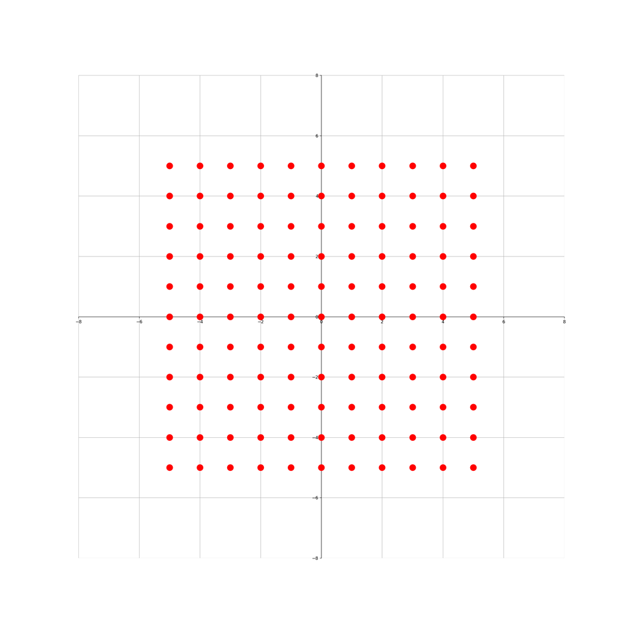

```python
x, y = np.arange(-5, 6, 1), np.arange(-5, 6, 1)
X, Y = np.meshgrid(x, y) #used to create a rectangular grid out of two given 1D arrays representing the Cartesian/Matrix data

fig, ax = plt.subplots(figsize = (20, 20)) #describes the layout of the figure
ax.scatter(X, Y, s = 200, color = 'red', zorder = 3) # set size of dot
ax.axis([-8, 8, -8, 8])

ax.spines['left'].set_position('zero') # alternative position is 'center'
ax.spines['right'].set_color('none')
ax.spines['bottom'].set_position('zero')
ax.spines['top'].set_color('none')
ax.grid()
```

## Visualisation of A System of Three Linear Equations

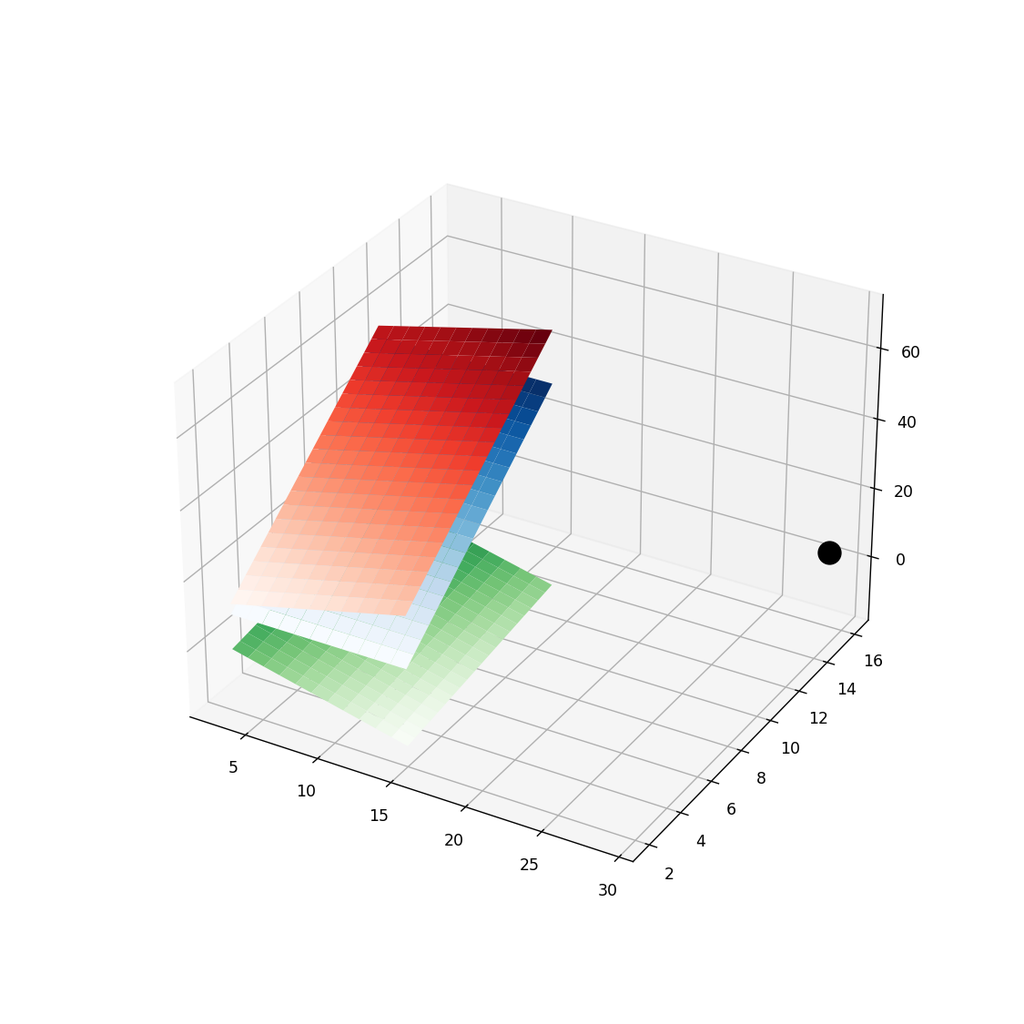

```python
x1 = np.linspace(15, 3, 12)
x2 = np.linspace(11, 2, 21)
X1, X2 = np.meshgrid(x1, x2)

fig = plt.figure(figsize = (9, 9))
ax = fig.add_subplot(111, projection = '3d')

X3 = X2 - X1
ax.plot_surface(X1, X2, X3, cmap ='Greens', alpha = 1)

X3 = 5*X2 - 1
ax.plot_surface(X1, X2, X3, cmap ='Blues', alpha = 1)

X3 = 5*X2 + X1 - 1
ax.plot_surface(X1, X2, X3, cmap ='Reds', alpha = 1)

ax.scatter(29, 16, 3, s = 200, color = 'black')
plt.show()
```

The graph does not show the intersections of the planes. This issue is due to Matplotlib's rendering algorithm, which is not designed to real 3D graphics. Simply project a 3D object into 2D dimensions to 3D functionality.

## Linear Combination Visualization in 3D

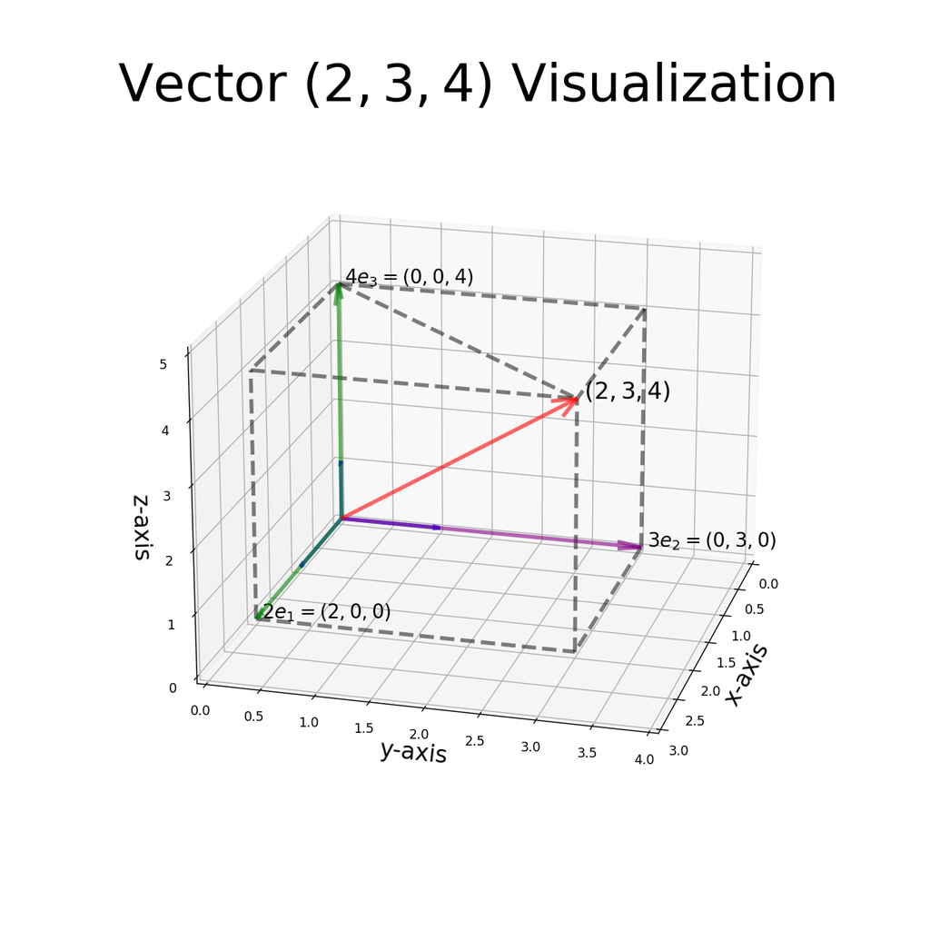

```python
    fig = plt.figure(figsize=(10,10))
    ax = fig.add_subplot(111, projection='3d')
    # Basis and Scalar Multiplid Vectors
    vec = np.array([[[0, 0, 0, 1, 0, 0]], # e1
                    [[0, 0, 0, 0, 1, 0]], # e2
                    [[0, 0, 0, 0, 0, 1]], # e3
                    [[0, 0, 0, 2, 0, 0]], # a* e1
                    [[0, 0, 0, 0, 3, 0]], # b* e2
                    [[0, 0, 0, 0, 0, 4]], # c* e3
                    [[0, 0, 0, 2, 3, 4]]]) # ae1 + be2 + ce3
    colors = ['blue','blue','blue','green','purple','green','red']
    for i in range(vec.shape[0]):
        X, Y, Z, U, V, W = zip(*vec[i,:,:])
        ax.quiver(X, Y, Z, U, V, W, length=1, normalize=False,
                  color = colors[i] ,arrow_length_ratio = .08, pivot = 'tail',
                  linestyles = 'solid',linewidths = 3, alpha =.6)

    #Rectangle Boxes
    dlines = np.array([[[2, 0, 0],[2, 3, 0]],
                      [[0, 3, 0],[2, 3, 0]],
                      [[0, 0, 4],[2, 3, 4]],
                      [[0, 0, 4],[2, 0, 4]],
                      [[2, 0, 4],[2, 3, 4]],
                      [[0, 0, 4],[0, 3, 4]],
                      [[0, 3, 4],[2, 3, 4]],
                      [[2, 0, 0],[2, 0, 4]],
                      [[0, 3, 0],[0, 3, 4]],
                      [[2, 3, 0],[2, 3, 4]]])
    colors = ['blue','blue','blue','green','purple','green','red','black','blue','black']
    for i in range(dlines.shape[0]):
        ax.plot(dlines[i,:,0], dlines[i,:,1], dlines[i,:,2], lw =3, ls = '--', color = 'black', alpha=0.5)

    #Text
    ax.text(x = 2, y = 3, z = 4, s= ' $(%0.d, %0.d, %.0d)$'% (2, 3, 4), size = 18)
    ax.text(x = 2, y = 0, z = 0, s= ' $%0.d e_1 = (%0.d, 0, 0)$'% (2,2), size = 15)
    ax.text(x = 0, y = 3, z = 0, s= ' $%0.d e_2 = (0, %0.d, 0)$'% (3,3), size = 15)
    ax.text(x = 0, y = 0, z = 4, s= ' $%0.d e_3 = (0, 0, %0.d)$' %(4,4), size = 15)


    # Axis Setting
    ax.grid()
    ax.set_xlim([0, 2+1])
    ax.set_ylim([0, 3+1])
    ax.set_zlim([0, 4+1])

    ax.set_xlabel('x-axis', size = 18)
    ax.set_ylabel('y-axis', size = 18)
    ax.set_zlabel('z-axis', size = 18)

    ax.set_title('Vector $(%0.d, %0.d, %.0d)$ Visualization' %(2, 3, 4), size = 40)

    ax.view_init(elev=20., azim=15)
```

```python
A = sy.MatrixA = sy.Matrix([[4,3,-5,2],[-2,-4,5,5],[4,3,-5,2]]);A
```

$\displaystyle \left[\begin{matrix}4 & 3 & -5 & 2\\-2 & -4 & 5 & 5\\4 & 3 & -5 & 2\end{matrix}\right]$

```python
B=A.rref();B
```

$\displaystyle \left( \left[\begin{matrix}1 & 0 & - \frac{1}{2} & \frac{23}{10}\\0 & 1 & -1 & - \frac{12}{5}\\0 & 0 & 0 & 0\end{matrix}\right], \ \left( 0, \ 1\right)\right)$

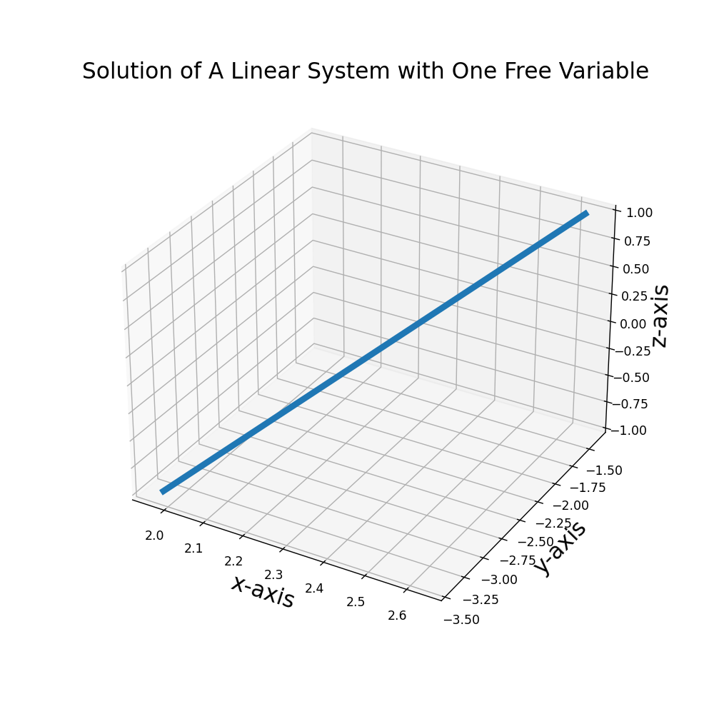

```python
fig = plt.figure(figsize = (8,8))
ax = fig.add_subplot(projection='3d')

t = np.linspace(-1, 1, 10)
c1 = 23/10+1/3*t
c2 = -12/5+t

ax.plot(c1, c2, t, lw = 5)

ax.set_xlabel('x-axis', size = 18)
ax.set_ylabel('y-axis', size = 18)
ax.set_zlabel('z-axis', size = 18)

ax.set_title('Solution of A Linear System with One Free Variable', size = 18)
plt.show()
```

A infinit line for one free variable case and Same infinite lines with two free variables.

## Linear Independence

A set of n vectors of length n is linearly independent if the matrix with these vectors as columns has a non-zero determinant

$$ \left[\begin{matrix}x\\y\\z\end{matrix}\right]=s \left[\begin{matrix}1\\-1\\1\end{matrix}\right]+t \left[\begin{matrix}1\\1\\1\end{matrix}\right]= \left[\begin{matrix}s+t\\-s+t\\s+t\end{matrix} \right] $$

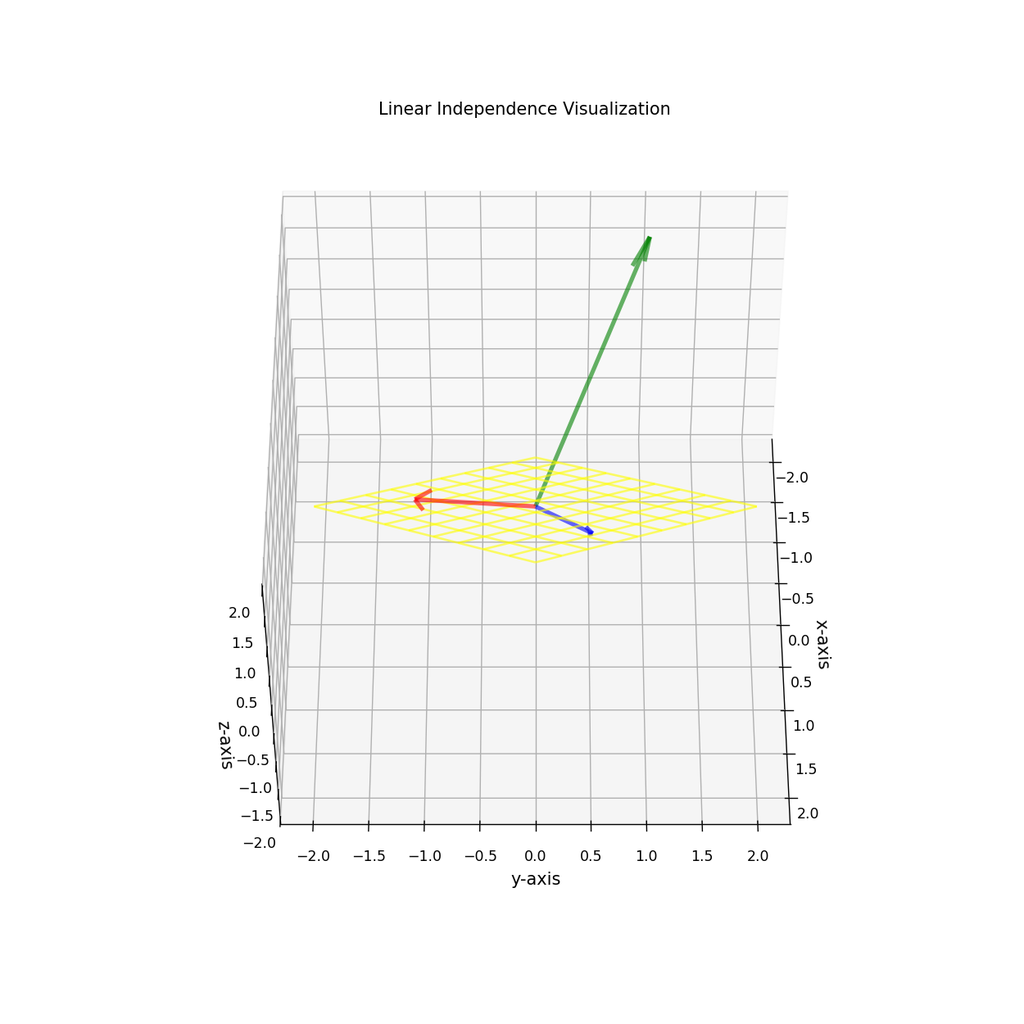

```python
fig = plt.figure(figsize = (10,10))
ax = fig.add_subplot(projection='3d')

s = np.linspace(-1, 1, 10)
t = np.linspace(-1, 1, 10)
S, T = np.meshgrid(s, t)

X = S+T
Y = -S+T
Z = S+T
ax.plot_wireframe(X, Y, Z, linewidth = 1.5, color = 'yellow', alpha = .6)

vec = np.array([[[0, 0, 0, 2, -1, 3]],#red
               [[0, 0, 0, 1, 1/2, 1]],#blue
               [[0, 0, 0, -1, 1, 3]]])#green
colors = ['r','b','g']
for i in range(vec.shape[0]):
    X, Y, Z, U, V, W = zip(*vec[i,:,:])
    #for setting arrows
    ax.quiver(X, Y, Z, U, V, W, length=1, normalize=False, color = colors[i],
              arrow_length_ratio = .1, pivot = 'tail',
              linestyles = 'solid',linewidths = 3, alpha = .6)

ax.set_title('Linear Independence Visualization')

ax.set_xlabel('x-axis', size = 12)
ax.set_ylabel('y-axis', size = 12)
ax.set_zlabel('z-axis', size = 12)

ax.view_init(elev=50., azim=0)
plt.show()
```

We can see that the greenvector is not in the plane spanned red and blue vector, thus they are linearly independent.